# **Multispecies Trait Data**

# **Cleaned up Data Download**

Cleaned data can be downloaded from Data.world as a .csv file. Because the dataset is so large, we filtered to only show some rows.

Hosting User: ehjkim  
Database: S17 DV Project 4  
Dataset Name: Pantheria.csv

Download Link: https://query.data.world/s/8ii6i7ylg3z01ki7f2tx4f81k

```r
source("../01 Data/Accessdataworld4.R")
```

```
## # A tibble: 5,416 × 55
##             v_0         v_1        v_2          v_3
##          <fctr>      <fctr>     <fctr>       <fctr>
## 1  Artiodactyla   Camelidae    Camelus  dromedarius
## 2     Carnivora     Canidae      Canis      adustus
## 3      Primates Pitheciidae Callicebus donacophilus
## 4      Rodentia  Cricetidae    Calomys     expulsus
## 5  Soricomorpha   Soricidae  Crocidura          voi
## 6  Soricomorpha   Soricidae  Crocidura        vorax
## 7  Soricomorpha   Soricidae  Crocidura     vosmaeri
## 8  Soricomorpha   Soricidae  Crocidura      watasei
## 9  Soricomorpha   Soricidae  Crocidura    whitakeri
## 10 Soricomorpha   Soricidae  Crocidura      wimmeri
## # ... with 5,406 more rows, and 51 more variables: v_4 <fctr>, v_5 <int>,
## #   v_6 <dbl>, v_7 <dbl>, v_8 <dbl>, v_9 <dbl>, v_10 <dbl>, v_11 <dbl>,
## #   v_12 <dbl>, v_13 <int>, v_14 <dbl>, v_15 <dbl>, v_16 <int>,
## #   v_17 <dbl>, v_18 <dbl>, v_19 <dbl>, v_20 <dbl>, v_21 <dbl>,
## #   v_22 <dbl>, v_23 <dbl>, v_24 <dbl>, v_25 <dbl>, v_26 <dbl>,
## #   v_27 <dbl>, v_28 <dbl>, v_29 <int>, v_30 <int>, v_31 <int>,
## #   v_32 <dbl>, v_33 <dbl>, v_34 <dbl>, v_35 <fctr>, v_36 <dbl>,
## #   v_37 <dbl>, v_38 <dbl>, v_39 <dbl>, v_40 <dbl>, v_41 <dbl>,
## #   v_42 <dbl>, v_43 <dbl>, v_44 <dbl>, v_45 <dbl>, v_46 <dbl>,
## #   v_47 <int>, v_48 <dbl>, v_49 <dbl>, v_50 <dbl>, v_51 <dbl>,
## #   v_52 <dbl>, v_53 <dbl>, v_54 <dbl>
##            v_0                     v_1                 v_2
##  Rodentia    :2277   Muridae         : 730   Crocidura   : 172
##  Chiroptera  :1116   Cricetidae      : 681   Myotis      : 103
##  Soricomorpha: 428   Vespertilionidae: 407   Rhinolophus :  77
##  Primates    : 376   Soricidae       : 376   Sorex       :  77
##  Carnivora   : 286   Sciuridae       : 278   Hipposideros:  67
##  Artiodactyla: 240   Pteropodidae    : 186   Rattus      :  66
##  (Other)     : 693   (Other)         :2758   (Other)     :4854
##         v_3                         v_4            v_5
##  australis:  15   Abditomys latidens  :   1   Min.   :0.0000
##  thomasi  :  15   Abeomelomys sevia   :   1   1st Qu.:0.0000
##  macrotis :  14   Abrawayaomys ruschii:   1   Median :0.0000
##  major    :  14   Abrocoma bennettii  :   1   Mean   :0.5583
##  grandis  :  11   Abrocoma boliviensis:   1   3rd Qu.:1.0000
##  minor    :  11   Abrocoma budini     :   1   Max.   :3.0000
##  (Other)  :5336   (Other)             :5410
```

[output cut: 125 more lines]

```
## 5399    0    0  0.00  0.00    0                                     -999
## 5400    0    0  0.00  0.00    0                                     -999
## 5406    1    0 18.33 12.05    0               730;786;890;1297;1822;2655
##      v_36 v_37 v_38 v_39      v_40  v_41  v_42  v_43 v_44  v_45  v_46 v_47
## 5397    0    0    0    0 2045005.1  0.22  6.04  1.58 35.2 13.32 10.08    0
## 5398    0    0    0    0       0.0  0.00  0.00  0.00  0.0  0.00  0.00    0
## 5399    0    0    0    0       0.0  0.00  0.00  0.00  0.0  0.00  0.00    0
## 5400    0    0    0    0  153013.4 35.10 28.80 32.04 82.2 77.85 80.07    0
## 5406    0    0    0    0       0.0  0.00  0.00  0.00  0.0  0.00  0.00    0
##       v_48 v_49 v_50   v_51   v_52    v_53    v_54
## 5397 51.76    1  0.1 148.27 242.80 1333.83 1550.28
## 5398  0.00    0  0.0   0.00   0.00    0.00    0.00
## 5399  0.00    0  0.0   0.00   0.00    0.00    0.00
## 5400 24.41    0  0.0  52.17  11.07  510.72   60.07
## 5406  0.00    0  0.0   0.00   0.00    0.00    0.00
```

# **Tableau / Tableau Action Generated Visualizations**

**Descriptions:** Refer to visualization captions for individual descriptions.

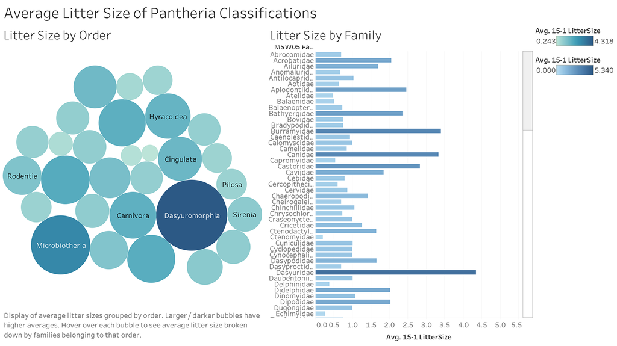

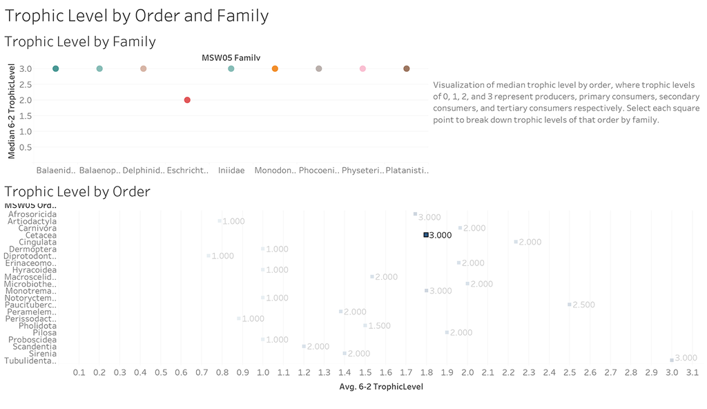

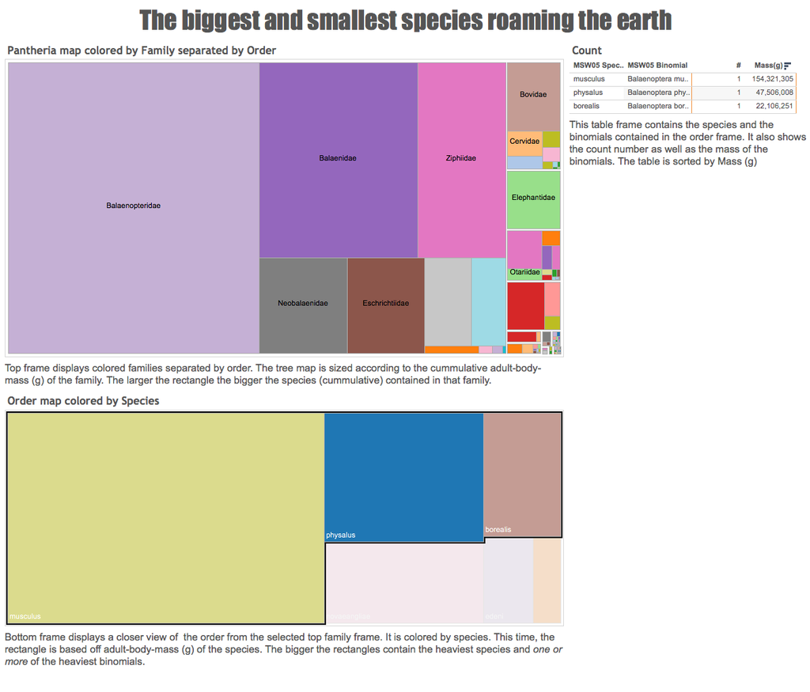

# **Shiny Visualization and Published Application**

**Description:** A static .png of the Shiny application, as well as a link to the live published version. Looks at sexual maturity age with respect to max longevity for the orders.

Published Link: https://frannyfang.shinyapps.io/shinyactions1/

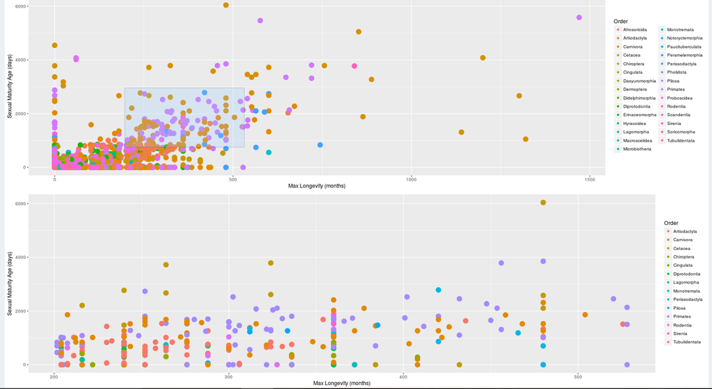